# Machine Learning Overview

Prof.ssa Ileana Baldi  
UBEP

## Course Outline week 2

**Machine learning overview**

1. Performance assessment
   - model evaluation
   - model selection
2. Resampling methods
   - Cross-validation
   - Bootstrap

## Performance assessment

Loss functions for numerical ouput:

$$L(Y,\hat{f}(X))=\begin{cases}
|Y-\hat{f}(X)| \\
(Y-\hat{f}(X))^2
\end{cases}$$

Loss functions for categorical ouput:
$$L(Y,\hat{f}(X))=\begin{cases}
I(Y \ne\hat{f}(X)) \\
-2{log(\hat p_k(X))}
\end{cases}$$

## Test vs training error rate

- *Training error rate* is simply the average error from a statistical learning method that uses predictions based on the data that was used to fit the model in the first place:

$$\frac 1 n \sum_{i=1}^n L(y_i,\hat{f}(x_i))$$

$$\mathit{E}(L(Y,\hat{f}(X))$$

## Test vs training error rate

- We utilize the test error rate to measure model performance, since training error rate can dramatically over-estimate real-world performance.

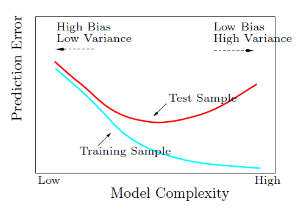

(The Elements of Statistical Learning. Hastie T, Tibshirani R, Friedman. Springer 2008)

## Test error

There are two common approaches to estimate test error:

1. We can directly estimate the test error, using either a validation set approach or a cross-validation approach.
2. We can indirectly estimate test error by making an adjustment to the training error to account for the bias due to overfitting (e.g. AIC, BIC,…)

## Goals

- Model selection: estimating the performance of different models in order to choose the best one.
- Model assessment: having chosen a final model, estimating its test error on new data.